# Estudio Datos Vino. Depuración de variables

Vamos a contar el número de valores únicos de las variables numéricas por si nos hemos dejado algo por ahí.

```r
# Cuento el número de valores diferentes para las numúricas
sapply(Filter(is.numeric, datos),function(x) length(unique(x)))
```

```
##             ID      Beneficio         Acidez   AcidoCitrico         Azucar
##           6365            983            659            523           1639
##  CloruroSodico       Densidad             pH       Sulfatos        Alcohol
##           1407           3614            437            544            312
##  PrecioBotella CalifProd_cont
##            598             13
```

```r
# Distribuciones de las variables. Vistazo rápido
summary(datos)
```

```
##        ID          Beneficio      Compra       Acidez         AcidoCitrico
##  Min.   :    2   Min.   :   0.0   0:1367   Min.   :-2.7900   Min.   :-3.2400
##  1st Qu.: 3980   1st Qu.: 236.0   1:4998   1st Qu.: 0.1300   1st Qu.: 0.0200
##  Median : 8065   Median : 480.0            Median : 0.2800   Median : 0.3100
##  Mean   : 8011   Mean   : 452.4            Mean   : 0.3312   Mean   : 0.3144
##  3rd Qu.:12027   3rd Qu.: 671.0            3rd Qu.: 0.6500   3rd Qu.: 0.5800
##  Max.   :16128   Max.   :1568.0            Max.   : 3.6800   Max.   : 3.8600
##
##      Azucar        CloruroSodico         Densidad            pH
##  Min.   : -127.1   Min.   :-1.17100   Min.   :0.8881   Min.   :0.540
##  1st Qu.:    0.9   1st Qu.:-0.03275   1st Qu.:0.9882   1st Qu.:2.960
##  Median :    5.0   Median : 0.04600   Median :0.9944   Median :3.190
##  Mean   : 4718.7   Mean   : 0.05135   Mean   :0.9942   Mean   :3.202
##  3rd Qu.:   22.6   3rd Qu.: 0.14675   3rd Qu.:1.0006   3rd Qu.:3.460
##  Max.   :99999.0   Max.   : 1.35100   Max.   :1.0992   Max.   :6.050
##                    NA's   :299                         NA's   :195
##     Sulfatos          Alcohol          Etiqueta    CalifProductor Clasificacion
##  Min.   :-3.1200   Min.   : -4.50   R      :2380   2      :2430   *   :1535
##  1st Qu.: 0.2800   1st Qu.:  9.00   M      :1357   3      :2069   **  :1754
##  Median : 0.5000   Median : 10.50   B      :1282   4      : 690   *** :1074
##  Mean   : 0.5267   Mean   : 16.25   r      : 420   1      : 619   ****: 322
##  3rd Qu.: 0.8800   3rd Qu.: 12.80   m      : 230   5      : 264   ?   :1680
##  Max.   : 4.2100   Max.   :150.00   MM     : 216   6      : 122
##  NA's   :604                        (Other): 480   (Other): 171
##   Region     PrecioBotella    CalifProd_cont
##  1   :2059   Min.   : 1.000   Min.   : 0.000
##  2   :2067   1st Qu.: 1.420   1st Qu.: 2.000
##  3   :2132   Median : 2.190   Median : 3.000
##  NA's: 107   Mean   : 2.611   Mean   : 2.762
##              3rd Qu.: 3.440   3rd Qu.: 3.000
##              Max.   :11.440   Max.   :12.000
##
```

```r
# Ver el reparto de las categorías de las variables cualitativas
questionr::freq(datos$CalifProductor)
```

```
##       n    % val%
## 0    33  0.5  0.5
## 1   619  9.7  9.7
## 2  2430 38.2 38.2
## 3  2069 32.5 32.5
## 4   690 10.8 10.8
## 5   264  4.1  4.1
## 6   122  1.9  1.9
## 7    76  1.2  1.2
## 8    30  0.5  0.5
## 9    22  0.3  0.3
## 10    4  0.1  0.1
## 11    3  0.0  0.0
## 12    3  0.0  0.0
```

```r
# Para otros estadísticos
psych::describe(Filter(is.numeric, datos)) #hay otro describe en otra libreria
```

```
##                vars    n    mean       sd  median trimmed     mad     min
## ID                1 6365 8010.70  4654.94 8065.00 8006.18 5976.36    2.00
## Beneficio         2 6365  452.38   308.38  480.00  442.97  308.38    0.00
## Acidez            3 6365    0.33     0.79    0.28    0.33    0.43   -2.79
## AcidoCitrico      4 6365    0.31     0.86    0.31    0.31    0.42   -3.24
## Azucar            5 6365 4718.67 21192.55    5.00    8.67   17.20 -127.10
## CloruroSodico     6 6066    0.05     0.32    0.05    0.05    0.13   -1.17
## Densidad          7 6365    0.99     0.03    0.99    0.99    0.01    0.89
## pH                8 6170    3.20     0.68    3.19    3.20    0.37    0.54
## Sulfatos          9 5761    0.53     0.95    0.50    0.53    0.44   -3.12
## Alcohol          10 6365   16.25    25.60   10.50   10.85    2.67   -4.50
## PrecioBotella    11 6365    2.61     1.48    2.19    2.41    1.35    1.00
## CalifProd_cont   12 6365    2.76     1.32    3.00    2.63    1.48    0.00
##                     max     range  skew kurtosis     se
## ID             16128.00  16126.00  0.00    -1.19  58.35
## Beneficio       1568.00   1568.00  0.02    -0.65   3.87
## Acidez             3.68      6.47  0.03     1.82   0.01
## AcidoCitrico       3.86      7.10 -0.02     1.73   0.01
## Azucar         99999.00 100126.10  4.27    16.26 265.63
## CloruroSodico      1.35      2.52  0.01     1.79   0.00
## Densidad           1.10      0.21 -0.01     2.01   0.00
## pH                 6.05      5.51  0.00     1.69   0.01
## Sulfatos           4.21      7.33 -0.06     1.73   0.01
## Alcohol          150.00    154.50  4.10    15.53   0.32
## PrecioBotella     11.44     10.44  1.12     0.91   0.02
## CalifProd_cont    12.00     12.00  1.66     5.17   0.02
```

Distintas formas de echar el vistazo a las distribuciones de las variables, donde prestaremos atención al *summary* que nos informa sobre cuartiles y media, así como valores perdidos y máximos. Así, observamos que *azucar* tiene valores 99999 sospechosos y *sulfatos* 604 valores ausentes (NA), que alcohol debe tener distribución asimétrica positiva por valores posiblemente altos, de hecho es un % y no debería superar 100.

Podemos inspeccionar las distribuciones gráficamente para completar la exploración. Las funciones dfplot_box y dfplot_his están diseñadas para retornar una lista de boxplots o histrogramas de las variables continuas junto con los diagramas de barras para las variables categóricas (hacen uso de las funciones hist_cont, boxplot_cont y barras_cual). De esta forma podemos visualizar el dataset entero de un plumazo.

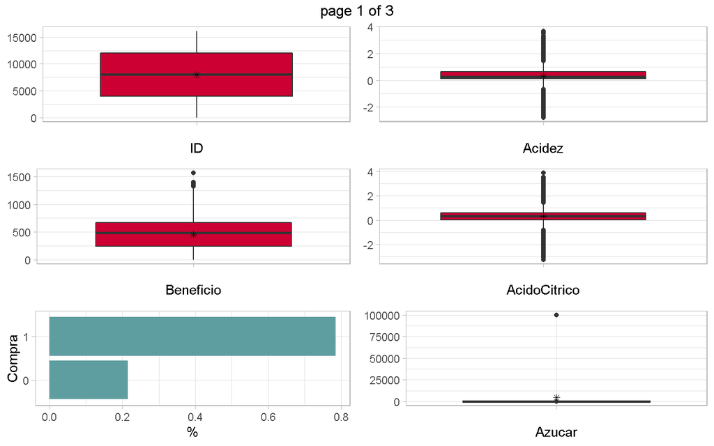

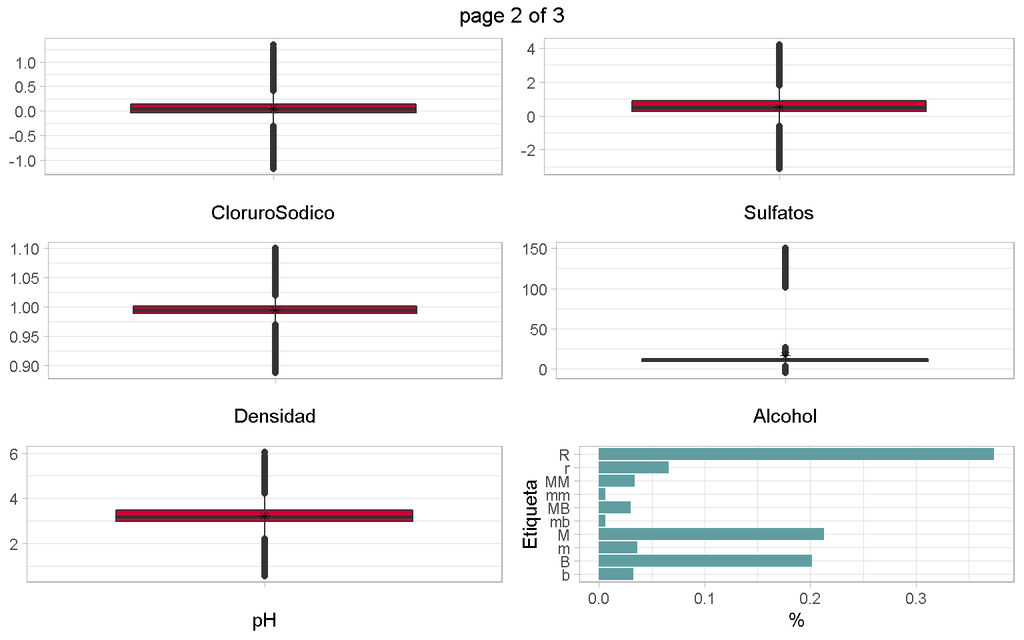

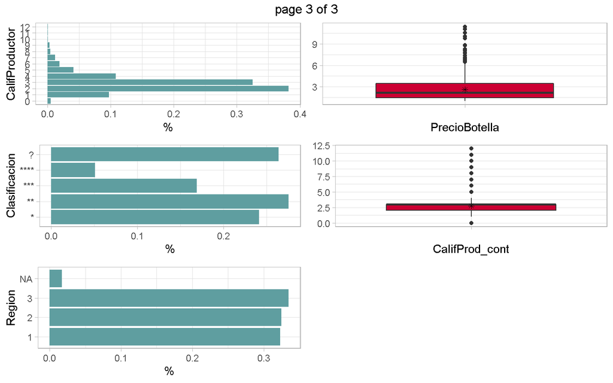

```r
# Inspección gráfica inicial
listaGraf <- dfplot_box(datos) #Boxplots
listaHist<-dfplot_his(datos) #Histogramas

# para presentar una rejilla de graficos a nuestro gusto
gridExtra::marrangeGrob(listaGraf, nrow = 3, ncol = 2)
```

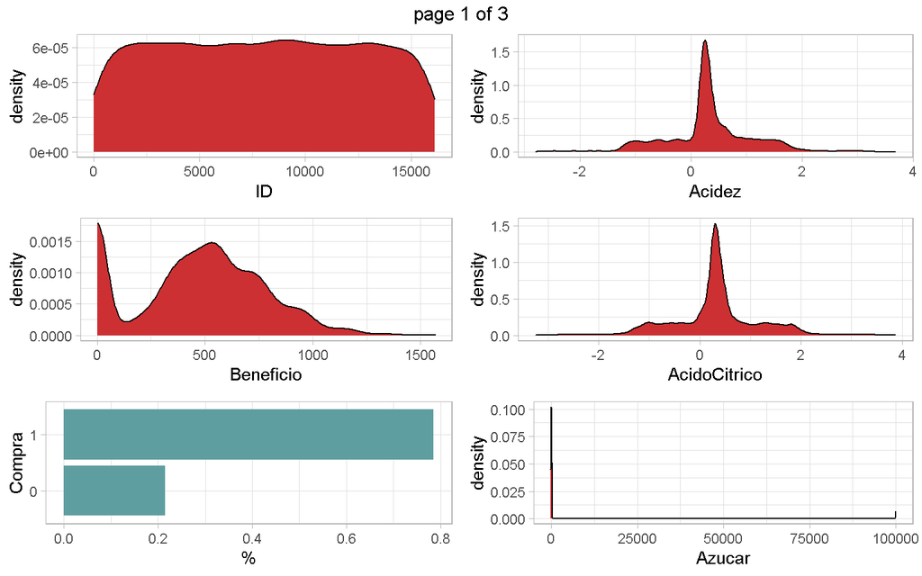

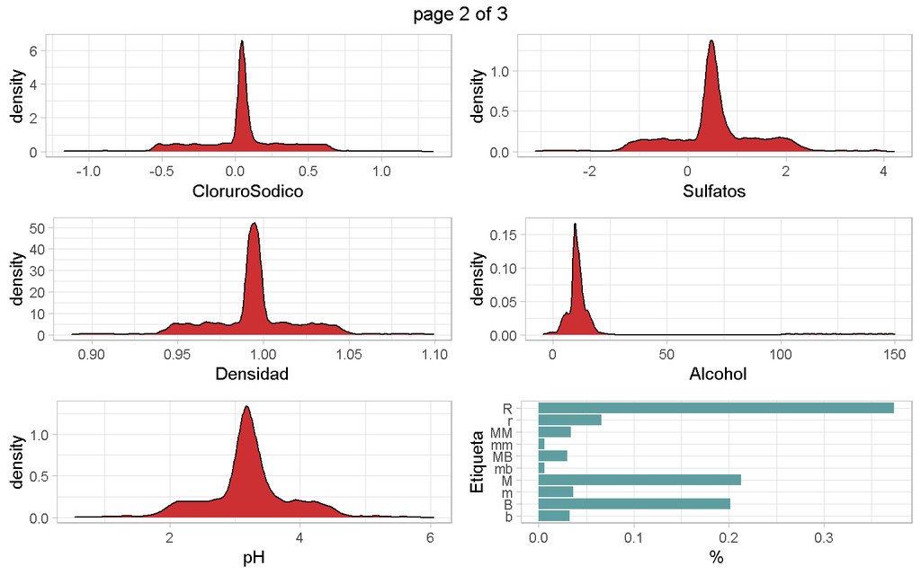

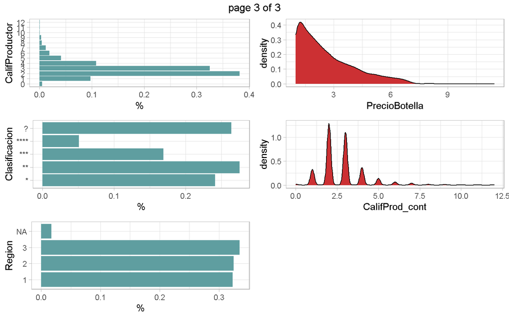

```r
gridExtra::marrangeGrob(listaHist, nrow = 3, ncol = 2)
```

### Corrección de errores detectados

```r
# Missings no declarados variables cualitativas (NSNC, ?)
datos$Clasificacion<-recode.na(datos$Clasificacion,"?")
```

```
## Recoded 1680 values to NA.
```

```r
# Missings no declarados variables cuantitativas (-1, 99999)
datos$Azucar<-replace(datos$Azucar,which(datos$Azucar==99999),NA)

# Valores fuera de rango
datos$Alcohol<-replace(datos$Alcohol, which((datos$Alcohol < 0)|(datos$Alcohol>100)), NA)

#Errores de escritura en variables cualitativas.
#datos$Etiqueta<-car::recode(datos$Etiqueta, "'b'='B';'m'='M';'mb'='MB';'mm'='MM';'r'='R'")

#En este caso, se puede usar también "toupper()" y aprovechamos para ordenar niveles
datos$Etiqueta<-factor(toupper(datos$Etiqueta), levels = c('MM','M','R','B','MB'))

#Variables cualitativas con categorías poco representadas
datos$CalifProductor<-car::recode(datos$CalifProductor, "c(0,1)='0-1';c(5,6,7,8,9,10,11,12)='5-12'")
```

Una vez libres de errores graves, las variables están preparadas para la gestión de outliers y missing. Para ello, es importante separa las variables objetivo y trabajar en el archivo de predictores. No es habitual tocar las variables objetivo puesto que representan nuestra verdad verdadera, son las variables de supervisión y se presuponen bien recogidas.

Imaginemos que se nos presenta la situación en la que tenemos valores missing en las objetivo, que deberíamos hacer? Pues tratar estas instancias como un conjunto de test sobre el que podríamos hacer predicciones y valorar si el modelo parece tener sentido. El problema es que no podremos evaluar la calidad de las estimaciones mediante el error cometido puesto que no tenemos su verdad verdadera.

```r
#Indico la variableObj, el ID y las Input
# los atípicos y los missings se gestionan sólo de las input
varObjCont<-datos$Beneficio
varObjBin<-datos$Compra
input<-as.data.frame(datos[,-(2:3)])
input$ID<-as.numeric(datos$ID)
```

## Valores atípicos

Para facilitarnos la vida y complementar la idea que tenemos ya sobre las distribuciones de las variables, llevamos a cabo un conteo de los valores que se consideran extremos según un consenso de dos criterios distintos. En primer lugar, se distingue variable simétrica o posiblemente no, para aplicar *media + 3 sd* ó *mediana + 8 mad*, respectivamente. Recordamos en este punto que todas las medidas de dispersión basadas en la mediana o cuartiles son muy poco sensibles a la presencia de asimetría en la distribución, siendo por ello más fiables en este caso. Por otro lado, aplicamos el clásico criterio del boxplot umbrales en *cuartil1 - 3IQR* y *cuartil3+ 3IQR*.

Antes de convertir aquellos valores detectados como outliers, valoramos la incidencia en cada variable contando la proporción de atípicos.

```r
##Atípicos
# Cuento el porcentaje de atípicos de cada variable.
# Si son muchos, elimino esas
# variables en la siguiente línea de código
sapply(Filter(is.numeric, input),
       function(x) atipicosAmissing(x)[[2]])/nrow(input)
```

```
##             ID         Acidez   AcidoCitrico         Azucar  CloruroSodico
##    0.000000000    0.016967793    0.016339356    0.018381775    0.016025137
##       Densidad             pH       Sulfatos        Alcohol  PrecioBotella
##    0.018853103    0.014454046    0.016653574    0.002985075    0.000000000
## CalifProd_cont
##    0.000000000
```

```r
# Tabla bonita para el % de atipicos por variable
t<-data.frame(sort(
  round(sapply(Filter(
    is.numeric, input),function(nOut) atipicosAmissing(
      nOut)[[2]])/nrow(input)*100,3), decreasing = T))
names(t)<-"% Outliers por variable"

# Formato normal
t
```

```
##                % Outliers por variable
## Densidad                         1.885
## Azucar                           1.838
## Acidez                           1.697
## Sulfatos                         1.665
## AcidoCitrico                     1.634
## CloruroSodico                    1.603
## pH                               1.445
## Alcohol                          0.299
## ID                               0.000
## PrecioBotella                    0.000
## CalifProd_cont                   0.000
```

```r
# Esta opción es útili para presentar tablas grandes en html
#kable(t) %>%
 # kable_styling(bootstrap_options = c("striped", "hover"))%>%
#scroll_box(width = "100%",height = "400px" )
```

Ya que la incidencia es baja, se decide transformar a missing los outliers encontrados

**Posponemos este paso para probar otros métodos disponibles en R**

Por supuesto, R es muy amplio y existen funciones para la gestión de outliers. Sin embargo, debido a que la identificación y tratamiento de outliers es un tema muy delicado que depende mucho de los datos que se están analizando, no hay claro consenso y se desaconseja la aplicación de métodos super automáticos para esta labor.

En cualquier caso, puede resultar de utilidad recurrir a métodos multivariantes (tienen en cuanta no solamente la información de la variable en cuestión sino más bien trabajan con cada registro mirando todas las variables introducidas). De esta forma, se pueden identificar registros completos que se consideran atípicos respecto a la distribución general de los datos.

Varias aproximaciones como mecanismos basados en clustering (función outliers.ranking), ciertos test estadísticos que arrojan la probabilidad de que una observación sea outlier (paquete outliers) y un método que probaremos basado en vecinos cercanos.

- El método *Local Outlier Factor* (DMwR2) utiliza vecinos cercanos (es decir que sus distancias en el espacio R^k son pequeñas, lo que viene a decir que la distribución general de todas las variables es parecida) para generar un factor que toma valores para cada registro que son mayores cuanto más atípico se considera. Normalmente valores cercanos a 1 representan observaciones medias y son los valores más altos los que cabe sospechar que pueden ser registros atípicos.

Entonces podemos adoptar la estrategia de calcular este factor y luego hacer una inspección de los registros más extremos para tomar conciencia de las razones por las que los son.

Precauciones:

- No acepta valores perdidos
- Alta dependencia del valor k (número de vecinos a considerar)

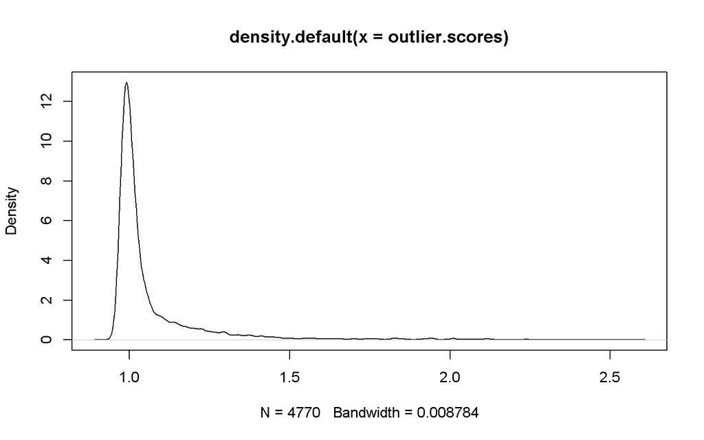

```r
# Aplicamos el algoritmo para obtener las puntuaciones
 outlier.scores <- lofactor(na.omit(Filter(is.numeric, input)), k=20)

# Pintamos la función de densidad de la distribución del factor
 plot(density(outlier.scores))
```

```r
# Extraemos la posición de los 5 registros más extremos
 outliers <- order(outlier.scores, decreasing=T)[1:5]

# Filtramos el dataset introducido para observar estos registros
(na.omit(Filter(is.numeric, input))[outliers,] ->out5)
```

```
##         ID Acidez AcidoCitrico Azucar CloruroSodico Densidad   pH Sulfatos
## 1714  4285  -0.77         0.29  130.2         0.042  0.99304 3.19     0.47
## 6288 15918   0.41         0.17  129.6        -0.079  0.96961 2.95     0.45
## 1285  3191  -0.52         0.42  123.2        -0.158  1.04320 3.26     1.71
## 104    216   0.22        -0.60  137.6         0.316  0.99834 3.05     1.79
## 4481 11266  -1.15         0.09  132.9        -0.499  0.98646 3.45     0.39
##      Alcohol PrecioBotella CalifProd_cont
## 1714    10.3          3.79              2
## 6288    12.7          1.55              2
## 1285    15.6          1.38              2
## 104      9.1          6.18              2
## 4481     9.1          1.59              2
```

```r
 # Me guardo los ID de estos registros para luego
 out5$ID -> ID_out5
```

Estaría bien compararlos con el vector de valores medios (o medianos) de las distribuciones de las variables para poder valorar cuales son las características más extremas.

```r
data.frame(t(round(apply(na.omit(Filter(is.numeric, input)),2,mean),3)))
```

```
##         ID Acidez AcidoCitrico Azucar CloruroSodico Densidad    pH Sulfatos
## 1 7990.766  0.329        0.327  5.664         0.054    0.994 3.193    0.526
##   Alcohol PrecioBotella CalifProd_cont
## 1  10.591         2.613          2.757
```

```r
data.frame(t(round(apply(na.omit(Filter(is.numeric, input)),2,median),3)))
```

```
##     ID Acidez AcidoCitrico Azucar CloruroSodico Densidad   pH Sulfatos Alcohol
## 1 8064   0.28         0.31    4.1         0.046    0.994 3.19      0.5    10.4
##   PrecioBotella CalifProd_cont
## 1          2.18              3
```

Es evidente que la variable azucar toma valores muy altos para los registros analizados pero, hay que tener en cuenta que la distribución de dicha variable tiene colas pesadas, lo que indica que existe gran carga de valores extremos a ambos lados de la media. Veamos de nuevo la distribución.

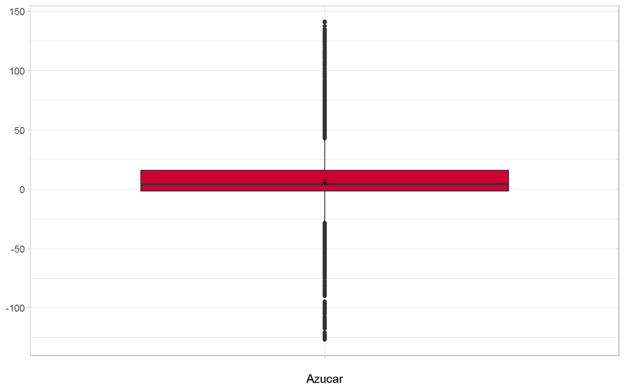

```r
boxplot_cont(input$Azucar,nombreEje = 'Azucar')
```

Efectivamente estamos ante una distribución muy apuntada (muchos valores centrales) pero con gran carga de observaciones fuera de los bigotes del boxplot (a más de 1.5 veces el rango intercuartílico). Ante esta situación, sería muy peligroso utilizar alguno de los métodos que se pueden encontrar por ahí, como la eliminación de registros fuera de dichos bigotes ya que la merma en observaciones sería demasiado grande y nadie nos ha dicho que un valor de azucar de 70 sea descabellado… Es por esto que insisto en ser conservadores con la identificación de outliers, y por eso utilizamos 3 veces el rango intercuatílico en lugar de 1.5.

Comentamos el registro con ID = 216 que parece bastante extremo en general. Si observamos los valores de ácido cítrico, cloruro sódico y sulfatos, nos damos cuenta de que todos ellos están lejos de la media y mediana de la distribución. Por otra parte el precio de la botella es bastante alto. Este tipo de registros son los que merecerían una atención especial. Aún así, no podemos concluir a la ligera que se trate de errores de medición ni que estos valores sean outliers perse.

Como pequeño resumen, lo que buscamos con el tratamiento de outliers es identificar valores verdaderamente extremos y que no sea típicos, lo cual necesariamente implica que han de ser pocos!! Y esto es muy relevante. Si son el 20% de los registros…pues tal vez estamos ante dos poblaciones distintas… habría que abordar el problema de otra forma..tal vez tratar cada población por separado.

Lo que ahora me planteo es comparar esos 5 registros extremos detectados por lof y ver como quedarían tras la aplicación de nuestro método de detección univariante basado en el consenso de criterios conservadores. Para ello vamos a aplicar nuestra función atípicosAmissing con el argumento [[1]] para cambiar los outlier detectados por NA.

```r
# Modifico los atípicos como missings
input[,as.vector(which(sapply(
  input, class)=="numeric"))]<-sapply(Filter(
    is.numeric, input),function(x) atipicosAmissing(x)[[1]])


# Filtramos los ID del top 5 de outliers detectados por lof
input[input$ID %in% ID_out5,]
```

```
##         ID Acidez AcidoCitrico Azucar CloruroSodico Densidad   pH Sulfatos
## 104    216   0.22        -0.60     NA         0.316  0.99834 3.05     1.79
## 1285  3191  -0.52         0.42     NA        -0.158  1.04320 3.26     1.71
## 1714  4285  -0.77         0.29     NA         0.042  0.99304 3.19     0.47
## 4481 11266  -1.15         0.09     NA        -0.499  0.98646 3.45     0.39
## 6288 15918   0.41         0.17     NA        -0.079  0.96961 2.95     0.45
##      Alcohol Etiqueta CalifProductor Clasificacion Region PrecioBotella
## 104      9.1        R              2             *      1          6.18
## 1285    15.6        B              2            **      2          1.38
## 1714    10.3        B              2          <NA>      1          3.79
## 4481     9.1        M              2           ***      3          1.59
## 6288    12.7        M              2             *      3          1.55
##      CalifProd_cont
## 104               2
## 1285              2
## 1714              2
## 4481              2
## 6288              2
```

Observamos que bajo nuestro compendio de criterios transformamos a NA la variable azucar de todos los registros, quedando las demás variables sin alteraciones. Es evidente que el método de los vecinos ha presentado gran dependencia de la variable Auzucar. Esto puede deberse a la diferencia en escala de medida, haciendo que valores más grandes tengan mayor peso en la puntuación final obtenida.

Muchas alternativas disponibles, lo importante es conocer las fortalezas y debilidades de cada uno y aplicarlo con lógica según resulte más conveniente para los datos que manejamos.

## Valores perdidos

Entramos de lleno en la segunda gran gestión que debemos llevar a cabo antes de la modelización. Los archiconocidos valores perdidos. En primer lugar comentar que, llegados a este punto tenemos valores perdidos de dos fuentes distintas, por una parte los que vienen “de serie” en el dataset que podemos asociar a falta de medida en la recogida de los datos y aquí existe toda una teoría sobre los mecanismos de aparición de dichos missing, completamente al azar (MCAR), al azar(MAR) o nada de azar y existe patrón (MNAR).

Dejo por aquí un poco más de información y diversos métodos propuestos para la imputación de estos valores.

https://stefvanbuuren.name/fimd/sec-MCAR.html

Nuestro objetivo, en este limitado módulo, será valorar la incidencia de los valores perdidos y conocer los métodos usuales de imputación univariante (cada variable independientemente de las otras) con sus pros y contras.

Que podemos hacer con los missings?

1. Nada

Podemos obviar la presencia de valores perdidos y ya el modelo se encargará de quitarlos “por lista”, es decir, eliminar del análisis toda observación con al menos un NA. Esto es habitual y se puede hacer, ahora bien no está exento de peligros. Veamos.

- Peligro de los missings cruzados. Imaginamos el caso en que tenemos 10 variables y 100 registros y cada una de ellas tiene un 5% de perdidos…No parece mucho con lo cual los quitamos por lista. Nuestro pensamiento es 5% pero, si se da el caso de que los NA de cada variable aparecen en registros distintos…entonces tenemos 5*10= 50% de los registros con al menos un perdido…hemos perdido la mitad de la información!!!
- Sesgo por valores perdidos. El simple hecho de eliminar observaciones por el mero hecho de que presenten perdidos puede introducir un importante sesgo de selección de registros en los modelos. Imaginemos que la gente mayo tiende a no contestar ciertas preguntas en una encuesta, eliminamos y nos quedamos con muy poca gente mayor por lo que las conclusiones con toda seguridad estarán sesgadas hacia los jóvenes.
2. Imputar sus valores.

No queremos exponernos a lo anterior por lo que se puede adoptar la estrategia de asignar un valor a estos datos no conocidos.

- Imputación por valores centrales (media, mediana): Muy habitual asignar valores centrales ya que no alteran la distribución de las variables como tal. El gran inconveniente de este método es a subestimación de la verdadera varianza de la variable ya que estamos centrando demasiado la distribución haciendo que artificialmente su varianza se reduzca, en ocasiones muy drásticamente.
- Imputación por valores aleatorios: Si no queremos centrar tanto la distribución, podemos optar por asignar al azar valores observados de las distribuciones de cada variable a los registros con NA. De esta forma, cualquier valor en el rango observado puede ser asignado a los faltantes. El gran inconveniente de esto es la dependencia del azar.
- Imputación por modelos multivariantes: Muchas opciones en este apartado. Existen métodos que tienen en cuenta los valores observados de otras variables para asignar el valor más “plausible” a la variable perdida en un sentido conjunto. Una de las alternativas es generar imputaciones por un modelo de regresión por ejemplo, así para imputar Azucar utilizaremos un modelo que estime los valores de azucar en base a las demás variables (que se ajustará con los valores validos por lista) y posteriormente predeciremos los perdidos de azucar mediante este modelo generado. De esta misma forma existen modelos de imputación por random forest (missforet), vecinos más cercanos (knn), cadenas de Markov (hmisc, amelia) y gran cantidad de aproximaciones de imputación múltiple (imputar n veces y promediar). El mayor problema de estos métodos suele radicar en el posible sobreajuste a los datos de training.

Podemos echar un vistazo a la correlación en la existencia de missings para valorar si existe algún patrón de aparición de los mismos. En caso de que observemos patrones de aparición, podemos tirar del hilo e indagar el porqué de ese comportamiento para decidir el método más adecuado para imputar. En este caso no observamos patrón alguno.

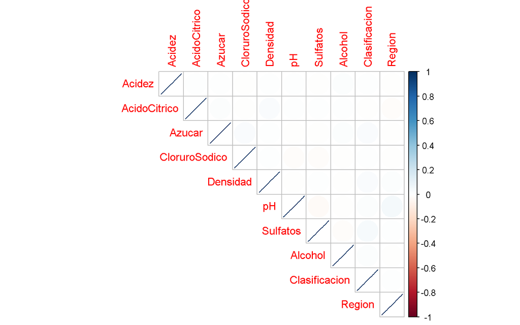

```r
## MISSINGS
#Busco si existe algún patrón en los missings, que me pueda ayudar a entenderlos
corrplot(cor(is.na(input[colnames(
  input)[colSums(is.na(input))>0]])),method = "ellipse",type = "upper")
```

```r
#No se aprecia ningún patrón
```

El primer paso es valorar la incidencia de los valores perdidos ya que si no representan gran proporción, no existe gran peligro de cambio en la distribución de las variables con independencia del método utilizado para la imputación.

- Missings por variable.

```r
prop_missingsVars<-apply(is.na(input),2,mean) # Por variable

# Tabla bonita para el % de missing por variable
t<-data.frame(sort(prop_missingsVars*100, decreasing = T))
names(t)<-"% Missing por Variable"
t
```

```
##                % Missing por Variable
## Clasificacion               26.394344
## Sulfatos                    11.154753
## Azucar                       6.551453
## Alcohol                      6.394344
## CloruroSodico                6.300079
## pH                           4.509034
## Densidad                     1.885310
## Acidez                       1.696779
## Region                       1.681068
## AcidoCitrico                 1.633936
## ID                           0.000000
## Etiqueta                     0.000000
## CalifProductor               0.000000
## PrecioBotella                0.000000
## CalifProd_cont               0.000000
```

Cuidadito con clasificación…Esto recordemos que se debe a esa ? que hemos convertido en NA. Ya que estos valores representan más de 1/4 de los registros parece que se merecen una categoría propia!

```r
#Recategorizo categóricas con "suficientes" observaciones missings
input$Clasificacion<-car::recode(input$Clasificacion,"NA='Desconocido'",as.factor = T)
```

Controlado esto, vemos que sulfatos es la variable más peligrosa con un 11% de perdidos..Digamos que es la variable en la que mayores dudas tenemos respecto a la conservación de su distribución tras la imputación. Por lo demás, valores relativamente bajos.

- Missings por observación.

Calcularemos ahora el % de missings por observación y vamos a aplicar un truquiflor que a veces nos ayuda mucho a controlar las imputaciones. Se trata de generar una variable en el archivo que cuanta la proporción de perdidos que tiene cada registro. De esta forma siempre tenemos una huella de los registros con alta carga de imputaciones por si necesitamos saber algo sobre ellos en la etapa de modelado. Es más, esta será una variable que incluiremos en el modelo para valorar si puede generar un patrón de comportamiento respecto a la variable objetivo.

```r
#Proporción de missings por variable y observación
input$prop_missings<-apply(is.na(input),1,mean) # Por observación
summary(input$prop_missings)
```

```
##    Min. 1st Qu.  Median    Mean 3rd Qu.    Max.
## 0.00000 0.00000 0.00000 0.02787 0.06667 0.26667
```

Vamos a ordenar el archivo por la nueva variable creada para ver el aspecto.

```r
input %>% arrange(desc(prop_missings)) %>% slice_head(n=5)
```

```
##     ID Acidez AcidoCitrico Azucar CloruroSodico Densidad   pH Sulfatos Alcohol
## 1 4992   0.28         0.78     NA        -0.214       NA   NA     0.16     9.4
## 2  512  -0.16           NA   48.9        -0.304       NA 3.04     1.31      NA
## 3  676  -0.45         0.00     NA            NA  0.99500 3.54       NA     6.4
## 4 1495  -1.03         0.81     NA            NA  0.99550 2.54       NA     3.8
## 5 1813   0.81        -0.19    8.4         0.051  0.99756   NA       NA    14.8
##   Etiqueta CalifProductor Clasificacion Region PrecioBotella CalifProd_cont
## 1       MB              2           ***   <NA>          3.75              2
## 2        B              4           ***      1          1.10              4
## 3        R              2   Desconocido      3          2.97              2
## 4        R              2   Desconocido      1          4.06              2
## 5        R              3           ***   <NA>          3.13              3
##   prop_missings
## 1     0.2666667
## 2     0.2000000
## 3     0.2000000
## 4     0.2000000
## 5     0.2000000
```

El siguiente código pretende eliminar registros y observaciones con más de la mitad de su información perdida puesto que resulta arriesgado imputar tal cantidad de datos perdidos. Es evidente que en nuestro caso no aplica y si lo ejecutamos no habrá cambio alguno.

Es importante saber que tenemos que aplicar el mismo filtro a las variables objetivo para que al unir el input depurado con ellas, los registros cuadren!

```r
#elimino las observaciones y las variables con más de la mitad
# de datos missings (si no hay ninguna, no ejecuto este código)
input %>% filter(prop_missings< 0.5) %>% select(!(names(
  prop_missingsVars)[prop_missingsVars>0.5]))-> imput

#Actualizar las observaciones de las variables objetivo
varObjBin<-varObjBin[input$prop_missings<0.5]
varObjCont<-varObjCont[input$prop_missings<0.5]
```

Vamos a centrar nuestros esfuerzos en la imputación simple teniendo en cuenta únicamente las distribuciones marginales de las variables. Con la función ImputacionCuant() podemos aplicar imputaciones por media, mediana o aleatorio a las variables que presentan missings. Así mismo, se puede hacer uso de funciones de R como impute de Hmisc (aplicado en comentario). La diferencia que encuentro en la opción aleatorio (random en Hmisc) es que nuestra función asigna valores aleatorios pero con probabilidades según la función de distribución de la propia variable, siendo algo más probable asignar un valor más central que un valor más extremo. En Hmisc la aleatoriedad es pura hasta el punto que conozco.

```r
## Imputaciones
# Imputo todas las cuantitativas, seleccionar el tipo
# de imputación: media, mediana o aleatorio
input[,as.vector(which(sapply(input, class)=="numeric"))]<-sapply(
  Filter(is.numeric, input),function(x) ImputacionCuant(x,"aleatorio"))

# input[,as.vector(which(sapply(input, class)=="numeric"))]<-sapply(
#  Filter(is.numeric, input),function(x) Hmisc::impute(x,"random"))
```

Para las variables categóricas podemos utilizar moda (la categoría más representada) o aleatorio. Hmisc solamente tiene implementada la moda.

```r
# Imputo todas las cualitativas, seleccionar el tipo
# de imputación: moda o aleatorio
# Si solo se quiere imputar una, variable<-ImputacionCuali(variable,"moda")
input[,as.vector(which(sapply(input, class)=="factor"))]<-sapply(
  Filter(is.factor, input),function(x) ImputacionCuali(x,"aleatorio"))

# A veces se cambia el tipo de factor a character al imputar,
# así que hay que indicarle que es factor
input[,as.vector(which(sapply(input, class)=="character"))] <- lapply(
  input[,as.vector(which(sapply(input, class)=="character"))] , factor)

# Reviso que no queden datos missings
summary(input)
```

```
##        ID            Acidez         AcidoCitrico         Azucar
##  Min.   :    2   Min.   :-2.0300   Min.   :-2.2400   Min.   :-97.300
##  1st Qu.: 3980   1st Qu.: 0.1400   1st Qu.: 0.0400   1st Qu.: -0.600
##  Median : 8065   Median : 0.2900   Median : 0.3100   Median :  4.200
##  Mean   : 8011   Mean   : 0.3303   Mean   : 0.3162   Mean   :  5.768
##  3rd Qu.:12027   3rd Qu.: 0.6400   3rd Qu.: 0.5700   3rd Qu.: 15.800
##  Max.   :16128   Max.   : 2.6800   Max.   : 2.8800   Max.   :108.100
##  CloruroSodico         Densidad            pH           Sulfatos
##  Min.   :-0.91200   Min.   :0.9154   Min.   :1.220   Min.   :-2.290
##  1st Qu.:-0.02600   1st Qu.:0.9889   1st Qu.:2.970   1st Qu.: 0.290
##  Median : 0.04600   Median :0.9944   Median :3.190   Median : 0.500
##  Mean   : 0.05132   Mean   :0.9942   Mean   :3.204   Mean   : 0.532
##  3rd Qu.: 0.13800   3rd Qu.:1.0004   3rd Qu.:3.460   3rd Qu.: 0.850
##  Max.   : 1.01900   Max.   :1.0724   Max.   :5.230   Max.   : 3.360
##     Alcohol      Etiqueta  CalifProductor     Clasificacion  Region
##  Min.   : 0.00   B :1491   0-1 : 652      *          :1535   1:2090
##  1st Qu.: 9.00   M :1587   2   :2430      **         :1754   2:2098
##  Median :10.40   MB: 231   3   :2069      ***        :1074   3:2177
##  Mean   :10.59   MM: 256   4   : 690      ****       : 322
##  3rd Qu.:12.40   R :2800   5-12: 524      Desconocido:1680
##  Max.   :22.60
##  PrecioBotella    CalifProd_cont   prop_missings
##  Min.   : 1.000   Min.   : 0.000   Min.   :0.00000
##  1st Qu.: 1.420   1st Qu.: 2.000   1st Qu.:0.00000
##  Median : 2.190   Median : 3.000   Median :0.00000
##  Mean   : 2.611   Mean   : 2.762   Mean   :0.02787
##  3rd Qu.: 3.440   3rd Qu.: 3.000   3rd Qu.:0.06667
##  Max.   :11.440   Max.   :12.000   Max.   :0.26667
```

```r
# Es posible que quede algún missing sin imputar en variable numéricas...
# algún pequeño fallo en la función. La pasamos de nuevo si es necesario!
if (any(is.na(input))){
input[,as.vector(which(sapply(input, class)=="numeric"))]<-sapply(
  Filter(is.numeric, input),function(x) ImputacionCuant(x,"aleatorio"))
# Reviso que no queden datos missings
summary(input)
}

# Una vez finalizado este proceso, se puede considerar
# que los datos están depurados. Los guardamos
saveRDS(cbind(varObjBin,varObjCont,input),"datosVinoDep.RDS")
```

Ya tenemos los datos depurados para poder empezar con el modelado. Es importante saber que a la hora de modelar utilizaremos este nuevo conjunto **datosVinoDep** y no el original, que para eso nos lo hemos trabajado.